# Homework04

Ethan Gutknecht

10/11/2021

```r
knitr::opts_chunk$set(echo = TRUE)
library(tidyverse)
library(knitr)
library(GGally)
library(lindia)
library(ggfortify)
```

## Complete the following steps to conduct an analysis of the rice data.

#### 1. Read in the data and remove any columns from the data set that are not needed for the model. *(2pts)*

```r
# Read the TXT file into an object
rice_original <- read.table("rice.txt", header = TRUE)

rice_1 <- rice_original %>% select(adhesiveness, moistureContent, amyloseContent, proteinContent, waterAbsorption, swellingRatio, pH, solidsContent)

head(rice_1)
```

```
##   adhesiveness moistureContent amyloseContent proteinContent waterAbsorption
## 1      -372.64            14.7           23.5            8.3          206.42
## 2      -127.50            14.8           25.3            7.9          235.14
## 3       -77.36            14.5           23.2            7.9          220.71
## 4      -113.43            14.4           23.2            8.3          239.09
## 5      -242.15            14.4           22.1            8.5          230.29
## 6       -61.71            14.4           25.6            8.6          224.14
##   swellingRatio   pH solidsContent
## 1        237.50 6.38          8.84
## 2        217.65 6.90          7.43
## 3        250.00 6.75          6.29
## 4        243.75 6.81          4.28
## 5        253.33 6.88          8.57
## 6        218.75 6.92          6.29
```

#### 2. Construct a scatterplot matrix of all variables. Describe any discernible patterns you see. *(2pts)*

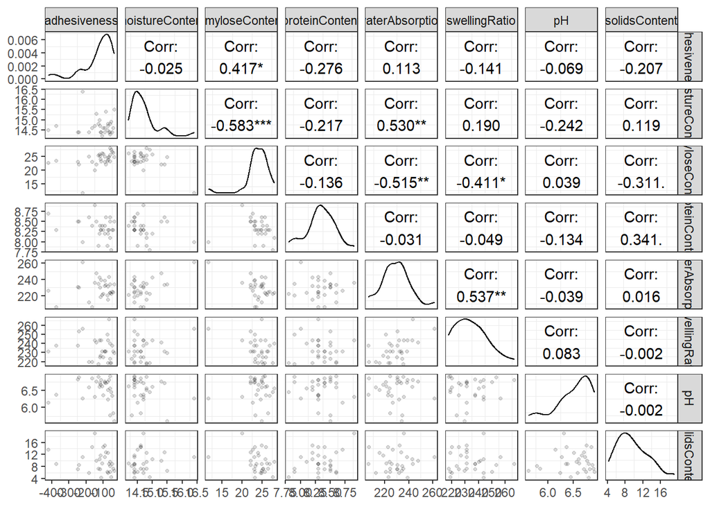

```r
ggpairs(rice_1,
        lower = list(continuous = wrap("points", alpha=0.15, size=0.95)),
        upper = list(continuous = wrap("cor", color="black") ) ) +
  theme_bw() +
  theme(panel.grid.major = element_blank() )
```

We can see that each graph has a sharp increase with it being offset to the left or right. No correlation is over 0.6 with many of the correlations being under 0.3.

#### 3. Fit the multiple regression modeling the adhesiveness as a function of moisture content, amylose content, protein content, water absorption, swelling ratio, pH, and solids content. *(2pts)*

```r
rice_lm_1 <- lm(abs(adhesiveness) ~ moistureContent + amyloseContent + proteinContent + waterAbsorption + swellingRatio + pH + solidsContent, data=rice_1)
summary(rice_lm_1)
```

```
##
## Call:
## lm(formula = abs(adhesiveness) ~ moistureContent + amyloseContent +
##     proteinContent + waterAbsorption + swellingRatio + pH + solidsContent,
##     data = rice_1)
##
## Residuals:
##    Min     1Q Median     3Q    Max
## -92.00 -41.60 -14.53  23.21 242.00
##
## Coefficients:
##                 Estimate Std. Error t value Pr(>|t|)
## (Intercept)      516.668   1461.267   0.354   0.7270
## moistureContent   -7.558     52.798  -0.143   0.8875
## amyloseContent   -19.086      7.792  -2.449   0.0227 *
## proteinContent    76.179     75.932   1.003   0.3267
## waterAbsorption   -3.768      1.845  -2.043   0.0532 .
## swellingRatio      1.195      1.569   0.761   0.4544
## pH                21.163     48.579   0.436   0.6673
## solidsContent     -1.032      4.982  -0.207   0.8378
## ---
## Signif. codes:  0 '***' 0.001 '**' 0.01 '*' 0.05 '.' 0.1 ' ' 1
##
## Residual standard error: 82.86 on 22 degrees of freedom
## Multiple R-squared:  0.3838, Adjusted R-squared:  0.1877
## F-statistic: 1.957 on 7 and 22 DF,  p-value: 0.1082
```

#### 4. Perform a residual analysis of the fitted model. Do you see any concerns regarding the assumptions we make in linear regression? *(2pts)*

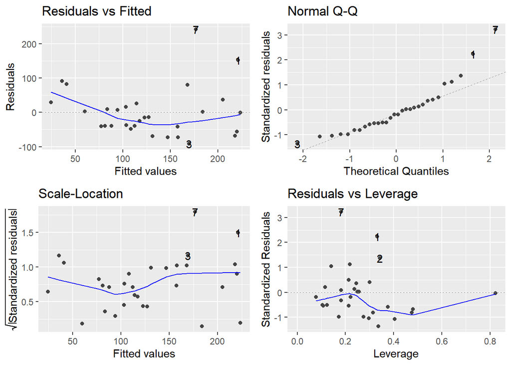

```r
# Check assumptions
autoplot(rice_lm_1)
```

The Q-Q plot starts to trend upwards towards the end of the data points aswell as the residuals vs fitted plot seems to not be very uniform aswell.

#### 5. Construct a Box-Cox transformation plot to the fitted model in Part 3, what is the optimal λ suggested? (Hint: adhesiveness values are all negative, and a Box-Cox plot only works for positive data. What can you do to make this plot work?) What type of transformation does this plot suggest? What other transformations are viable? *(2pts)*

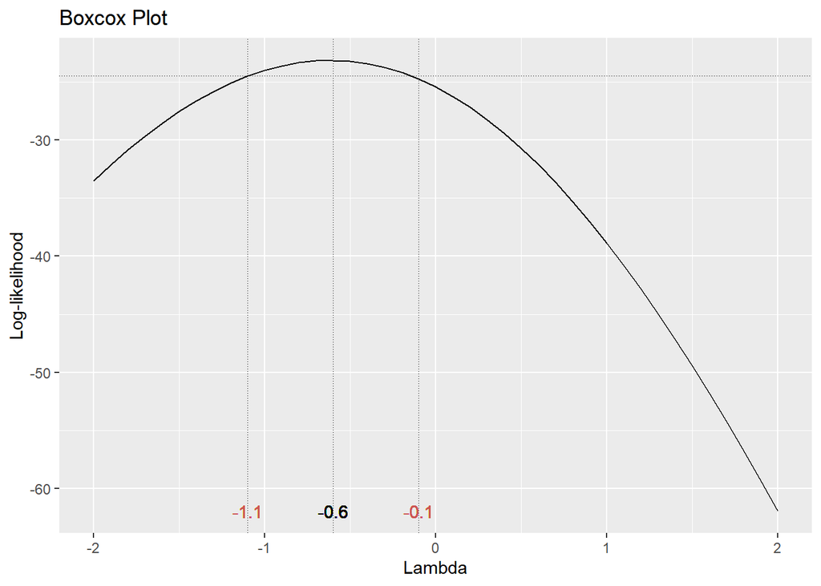

```r
# Construct box cox
gg_boxcox(rice_lm_1)
```

This box cox plot suggests that we should square our data by -0.6. We would also have to take the absolute value of the data before we squared to make it positive.

#### 6. Fit a multiple regression model using the transformation of adhesiveness chosen in Part 5 as a function of moisture content, amylose content, protein content, water absorption, swelling ratio, pH, and solids content. *(2pts)*

```r
# Create new lm model with log data
rice_lm_2 <- lm( abs(adhesiveness) ^ -0.6 ~ moistureContent + amyloseContent + proteinContent + waterAbsorption + swellingRatio + pH + solidsContent, data=rice_1)
```

#### 7. Perform a residual analysis of the fitted model in part 6. Does it appear that the transformation has improved the residuals plots? *(2pts)*

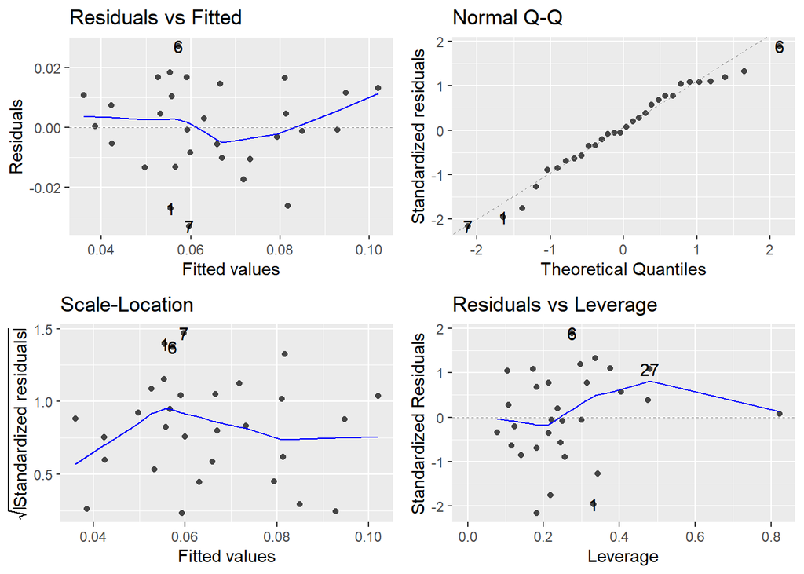

```r
# Check assumptions
autoplot(rice_lm_2)
```

```r
summary(rice_lm_2)
```

```
##
## Call:
## lm(formula = abs(adhesiveness)^-0.6 ~ moistureContent + amyloseContent +
##     proteinContent + waterAbsorption + swellingRatio + pH + solidsContent,
##     data = rice_1)
##
## Residuals:
##       Min        1Q    Median        3Q       Max
## -0.032908 -0.009685 -0.000151  0.011311  0.027111
##
## Coefficients:
##                   Estimate Std. Error t value Pr(>|t|)
## (Intercept)      1.025e-02  2.967e-01   0.035  0.97276
## moistureContent  6.627e-03  1.072e-02   0.618  0.54277
## amyloseContent   5.132e-03  1.582e-03   3.244  0.00373 **
## proteinContent  -1.123e-02  1.542e-02  -0.728  0.47410
## waterAbsorption  5.148e-04  3.745e-04   1.375  0.18312
## swellingRatio   -2.822e-05  3.185e-04  -0.089  0.93021
## pH              -2.734e-02  9.862e-03  -2.772  0.01112 *
## solidsContent   -5.282e-04  1.012e-03  -0.522  0.60674
## ---
## Signif. codes:  0 '***' 0.001 '**' 0.01 '*' 0.05 '.' 0.1 ' ' 1
##
## Residual standard error: 0.01682 on 22 degrees of freedom
## Multiple R-squared:  0.5671, Adjusted R-squared:  0.4294
## F-statistic: 4.118 on 7 and 22 DF,  p-value: 0.004947
```

Yes, since the redidual vs fitted is linear and centered aswell as the Q-Q plot is more concise, we can see that it fits the assumptions better than our original plot.

#### 9. Compare the transformed model in Part 6 to the original model in Part 3. Does this transformation change your results? Which model would you choose and why? *(2pts)*

Our first unmodified graph has a more curved residuals vs fitted plot and after doing some modifications, it is very linear. Aswell as this, the modified model is better since our Q-Q plot has points that are closer to the line.

#### 12. Use your chosen model from part 9 to predict, with 95% confidence, the adhesiveness of a rice serving with the following values. Make sure to construct a prediction interval, make sure you apply any necessary transformations, and make sure to interpret the interval in context. *(2pts)*

- Moisture Content = 14.9
- Amylose Content = 22.6
- Protein Content = 8.1
- Water Absorption = 211
- Swelling Ratio = 225
- pH = 6.6
- Solids Content = 5.2

```r
rice_predict <- data.frame(moistureContent  = 14.9,
                           amyloseContent  = 22.6,
                           proteinContent  = 8.1,
                           waterAbsorption = 211,
                           swellingRatio  = 225,
                           pH =  6.6,
                           solidsContent = 5.2)

predict(rice_lm_2, rice_predict, interval="pred")
```

```
##         fit        lwr        upr
## 1 0.0530974 0.01259997 0.09359484
```